# Autogenous - Selection scan with OutFLANK

Luciano V Cosme

2026-04-05

# Overview

This notebook implements the OutFLANK selection scan (Whitlock & Lotterhos 2015) to identify FST outlier loci in *Aedes albopictus* autogeny comparisons. The method fits a chi-squared distribution to a trimmed set of FST values to characterise the neutral FST distribution, then assigns q-values to identify outliers consistent with spatially heterogeneous selection.

> **Population label key:** AUT = AUTO, MAN = NON-AUTO, NEW = NON-AUTO-FIELD.

## 1. Libraries

```r
library(tidyverse)
library(here)
library(ggrepel)
# library(ggtext)  # not available during render
library(vcfR)
library(OutFLANK)
library(ggvenn)
```

## 2. Helper functions

```r
source(here("notebooks", "helpers", "my_theme2.R"))

# Load a VCF, recode diploid genotypes to 0/1/2/9, and return a named list
# with the genotype matrix G (transposed for OutFLANK), SNP IDs, positions,
# and population labels derived from sample name prefixes.
vcf_to_genotype_matrix <- function(vcf_path) {
  vcf       <- read.vcfR(vcf_path)
  geno      <- vcfR::extract.gt(vcf)
  snpNames  <- vcfR::getID(vcf)
  positions <- vcfR::getPOS(vcf)
  popNames  <- sapply(strsplit(colnames(geno), "_"), "[", 1)

  G <- matrix(9L, nrow = nrow(geno), ncol = ncol(geno))
  G[geno %in% c("0/0", "0|0")] <- 0L
  G[geno %in% c("0/1", "1/0", "1|0", "0|1")] <- 1L
  G[geno %in% c("1/1", "1|1")] <- 2L

  list(G = t(G), snpNames = snpNames, positions = positions, popNames = popNames)
}

# Apply the calibrated neutral FST distribution to the full SNP set,
# identify outliers, and return a data frame with OutlierFlag and q-values.
run_outflank_scan <- function(vcf_path, out_trim) {
  dat  <- vcf_to_genotype_matrix(vcf_path)
  locusNames3 <- paste(dat$snpNames, dat$positions, sep = ".")
  my_fst4 <- MakeDiploidFSTMat(dat$G, locusNames = locusNames3, popNames = dat$popNames)

  P1 <- pOutlierFinderChiSqNoCorr(
    my_fst4,
    Fstbar    = out_trim$FSTNoCorrbar,
    dfInferred = out_trim$dfInferred,
    qthreshold = 0.05,
    Hmin       = 0.1
  )
  P1 |> separate(LocusName, into = c("SNP_id", "LocusName"), sep = "\\.")
}

# Produce a Manhattan plot with outlier loci highlighted in magenta,
# annotated with SNP IDs at the highest-FST outlier per chromosome.
plot_outflank_manhattan <- function(P1, bim_path, title = NULL) {
  snps <- read_delim(
    bim_path,
    col_names      = FALSE,
    show_col_types = FALSE,
    col_types      = "ccidcc"
  )
  colnames(snps) <- c("Scaffold", "SNP", "Cm", "Position", "Allele1", "Allele2")

  my_fst4_split <- P1
  merged_df <- merge(my_fst4_split, snps, by.x = "SNP_id", by.y = "SNP") |>
    rename(Chromosome = Scaffold)

  df_sub  <- subset(merged_df, He > 0.1)
  my_out  <- P1$SNP_id[P1$OutlierFlag == TRUE]
  df_sub$highlight <- df_sub$SNP_id %in% my_out

  color_vector <- c("#CCF6D6", "#F6E1CC", "#CCD8F6")
  names(color_vector) <- unique(df_sub$Chromosome)

  highest_FST <- df_sub[df_sub$highlight, ]
  highest_FST <- highest_FST[
    highest_FST$FST == ave(highest_FST$FST, highest_FST$Chromosome, FUN = max), ]

  k_format <- function(x) paste0(format(x / 1e6, big.mark = "", scientific = FALSE), "k")

  ggplot(df_sub, aes(x = Position, y = FST)) +
    geom_point(aes(color = Chromosome), data = subset(df_sub, !highlight), size = .3) +
    geom_point(color = "magenta", data = subset(df_sub, highlight), size = .3) +
    scale_color_manual(values = color_vector, guide = "none") +
    labs(x = "Position", y = expression(F[ST]), title = title) +
    facet_wrap(~ Chromosome, scales = "free_x") +
    scale_x_continuous(labels = k_format) +
    my_theme() +
    theme(
      panel.spacing  = unit(.2, "lines"),
      plot.margin    = unit(c(1, 1, 2, 2), "lines"),
      plot.caption   = element_text(face = "italic", color = "#574E4E")
    ) +
    geom_text_repel(
      data = highest_FST,
      aes(label = SNP_id),
      size = 3, nudge_y = 0.01, segment.color = NA, max.overlaps = Inf
    )
}
```

## 3. OutFLANK: all three populations (MAN, NEW, AUT)

OutFLANK identifies FST outlier loci by fitting a chi-squared distribution to a trimmed set of FST values from quasi-independent SNPs, then applying the inferred neutral FST distribution to the complete SNP set.

### 3.1 LD pruning and neutral SNP calibration set

Extract intergenic SNPs and perform LD pruning to obtain a quasi-independent set.

```bash
plink2 \
--bfile output/quality_control/file7 \
--extract data/files/intergenic_SNPs.txt \
--indep-pairwise 5 1 0.1 \
--out output/outflank/indepSNP \
--silent;
grep 'samples\|variants\|remaining' output/outflank/indepSNP.log
```

```
## 60 samples (24 females, 26 males, 10 ambiguous; 60 founders) loaded from
## 110353 variants loaded from output/quality_control/file7.bim.
## --extract: 12112 variants remaining.
## 12112 variants remaining after main filters.
## --indep-pairwise (3 compute threads): 6667/12112 variants removed.
```

```bash
plink2 \
--bfile output/quality_control/file7 \
--extract output/outflank/indepSNP.prune.in \
--export vcf \
--make-bed \
--maf 0.1 \
--geno 0.2 \
--out output/outflank/intergenic \
--silent;
grep 'samples\|variants\|remaining' output/outflank/intergenic.log
```

```
## 60 samples (24 females, 26 males, 10 ambiguous; 60 founders) loaded from
## 110353 variants loaded from output/quality_control/file7.bim.
## --extract: 5445 variants remaining.
## --geno: 0 variants removed due to missing genotype data.
## 957 variants removed due to allele frequency threshold(s)
## 4488 variants remaining after main filters.
```

Compute FST values for the intergenic LD-pruned set and select low-FST loci (FST < 0.2) as the neutral calibration set.

```r
dat_intergenic <- vcf_to_genotype_matrix(here("output", "outflank", "intergenic.vcf"))
```

```
## Scanning file to determine attributes.
## File attributes:
##   meta lines: 8
##   header_line: 9
##   variant count: 4488
##   column count: 69
## Meta line 8 read in.
## All meta lines processed.
## gt matrix initialized.
## Character matrix gt created.
##   Character matrix gt rows: 4488
##   Character matrix gt cols: 69
##   skip: 0
##   nrows: 4488
##   row_num: 0
## Processed variant 1000Processed variant 2000Processed variant 3000Processed variant 4000Processed variant: 4488
## All variants processed
```

```r
my_fst_intergenic <- MakeDiploidFSTMat(
  dat_intergenic$G,
  locusNames = dat_intergenic$snpNames,
  popNames   = dat_intergenic$popNames
)
```

```
## Calculating FSTs, may take a few minutes...
```

```r
neutral_snps <- my_fst_intergenic |>
  filter(FST < 0.2 & FST >= -0.1) |>
  pull(LocusName)

write.table(
  neutral_snps,
  file      = here("output", "outflank", "neutral_SNPs.txt"),
  row.names = FALSE,
  quote     = FALSE,
  col.names = FALSE,
  sep       = "\n"
)
```

```bash
plink2 \
--bfile output/outflank/intergenic \
--export vcf \
--extract output/outflank/neutral_SNPs.txt \
--out output/outflank/neutral \
--silent;
grep "samples\|variants" output/outflank/neutral.log
```

```
## 60 samples (24 females, 26 males, 10 ambiguous; 60 founders) loaded from
## 4488 variants loaded from output/outflank/intergenic.bim.
## --extract: 3722 variants remaining.
## 3722 variants remaining after main filters.
```

Calibrate the neutral FST distribution.

```r
dat_neutral <- vcf_to_genotype_matrix(here("output", "outflank", "neutral.vcf"))
```

```
## Scanning file to determine attributes.
## File attributes:
##   meta lines: 8
##   header_line: 9
##   variant count: 3722
##   column count: 69
## Meta line 8 read in.
## All meta lines processed.
## gt matrix initialized.
## Character matrix gt created.
##   Character matrix gt rows: 3722
##   Character matrix gt cols: 69
##   skip: 0
##   nrows: 3722
##   row_num: 0
## Processed variant 1000Processed variant 2000Processed variant 3000Processed variant: 3722
## All variants processed
```

```r
my_fst_neutral <- MakeDiploidFSTMat(
  dat_neutral$G,
  locusNames = dat_neutral$snpNames,
  popNames   = dat_neutral$popNames
)
```

```
## Calculating FSTs, may take a few minutes...
```

```r
# NOTE: NumberOfSamples=60 is preserved from the original analysis.
# FLAG: OutFLANK documentation specifies this should be the number of
# populations (here: 3), not the number of individuals (60). This parameter
# may affect the fitted chi-squared degrees of freedom and outlier calls.
out_trim_3pop <- OutFLANK(
  FstDataFrame    = my_fst_neutral,
  Hmin            = 0.1,
  NumberOfSamples = 60,
  qthreshold      = 0.05
)
```

Diagnostic plots for the neutral FST fit.

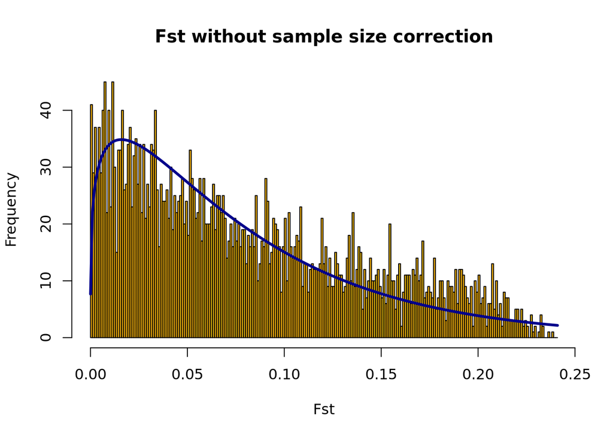

```r
OutFLANKResultsPlotter(
  out_trim_3pop,
  withOutliers      = TRUE,
  NoCorr            = TRUE,
  Hmin              = 0.1,
  binwidth          = 0.001,
  Zoom              = FALSE,
  RightZoomFraction = 0.05,
  titletext         = NULL
)
```

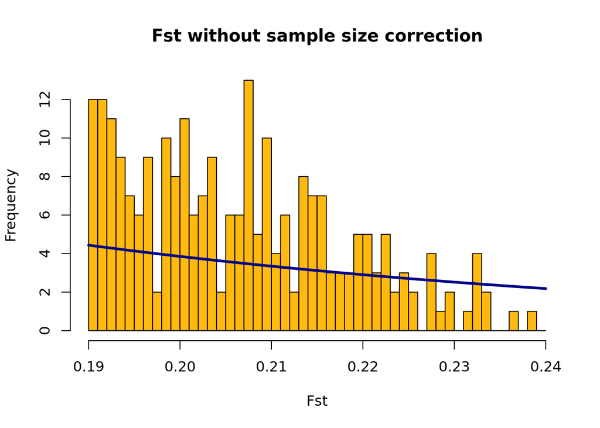

```r
OutFLANKResultsPlotter(
  out_trim_3pop,
  withOutliers      = TRUE,
  NoCorr            = TRUE,
  Hmin              = 0.1,
  binwidth          = 0.001,
  Zoom              = TRUE,
  RightZoomFraction = 0.05,
  titletext         = NULL
)
```

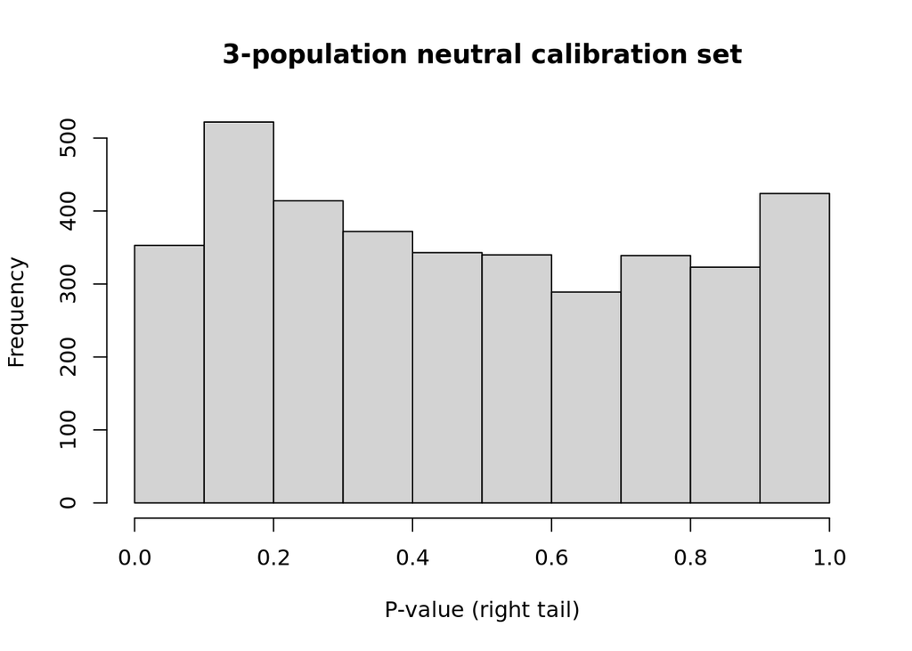

```r
hist(out_trim_3pop$results$pvaluesRightTail,
     xlab = "P-value (right tail)", main = "3-population neutral calibration set")
```

### 3.2 Scan across all loci

Apply the calibrated neutral FST distribution to the full LD-pruned SNP set.

```bash
plink2 \
--bfile output/quality_control/file7 \
--export vcf \
--extract output/quality_control/indepSNP.prune.in \
--make-bed \
--out output/outflank/autogenous \
--silent;
grep "samples\|variants" output/outflank/autogenous.log
```

```
## 60 samples (24 females, 26 males, 10 ambiguous; 60 founders) loaded from
## 110353 variants loaded from output/quality_control/file7.bim.
## --extract: 41849 variants remaining.
## 41849 variants remaining after main filters.
```

```r
P1_3pop <- run_outflank_scan(
  here("output", "outflank", "autogenous.vcf"),
  out_trim_3pop
)
```

```
## Scanning file to determine attributes.
## File attributes:
##   meta lines: 8
##   header_line: 9
##   variant count: 41849
##   column count: 69
## Meta line 8 read in.
## All meta lines processed.
## gt matrix initialized.
## Character matrix gt created.
##   Character matrix gt rows: 41849
##   Character matrix gt cols: 69
##   skip: 0
##   nrows: 41849
##   row_num: 0
## Processed variant 1000Processed variant 2000Processed variant 3000Processed variant 4000Processed variant 5000Processed variant 6000Processed variant 7000Processed variant 8000Processed variant 9000Processed variant 10000Processed variant 11000Processed variant 12000Processed variant 13000Process…
## All variants processed
## Calculating FSTs, may take a few minutes...
## [1] "10000 done of 41849"
## [1] "20000 done of 41849"
## [1] "30000 done of 41849"
## [1] "40000 done of 41849"
```

```r
my_out_3pop <- P1_3pop$SNP_id[P1_3pop$OutlierFlag == TRUE]
write.table(
  my_out_3pop,
  file      = here("output", "outflank", "SNPs_outFlank.txt"),
  row.names = FALSE,
  quote     = FALSE,
  col.names = FALSE,
  sep       = "\n"
)
```

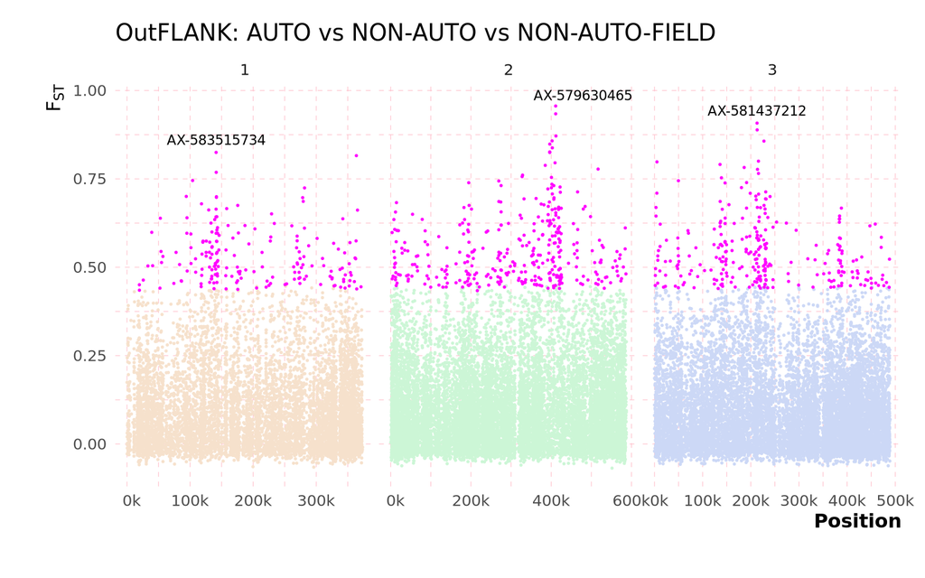

```r
p_3pop <- plot_outflank_manhattan(
  P1_3pop,
  here("output", "outflank", "autogenous.bim"),
  title = "OutFLANK: AUTO vs NON-AUTO vs NON-AUTO-FIELD"
)
print(p_3pop)
```

```r
ggsave(
  here("output", "outflank", "figures", "outFlank_outliers.pdf"),
  width = 8, height = 5, units = "in"
)
```

## 4. OutFLANK: NON-AUTO vs AUTO (MAN vs AUT)

### 4.1 Neutral SNP calibration set

```bash
plink2 \
--bfile output/outflank/man_aut \
--extract output/outflank/indepSNP.prune.in \
--export vcf \
--make-bed \
--out output/outflank/man_aut2 \
--silent;
grep 'samples\|variants\|remaining' output/outflank/man_aut2.log
```

```
## 38 samples (13 females, 15 males, 10 ambiguous; 38 founders) loaded from
## 41332 variants loaded from output/outflank/man_aut.bim.
## --extract: 3705 variants remaining.
## 3705 variants remaining after main filters.
```

```r
dat_ma2 <- vcf_to_genotype_matrix(here("output", "outflank", "man_aut2.vcf"))
```

```
## Scanning file to determine attributes.
## File attributes:
##   meta lines: 8
##   header_line: 9
##   variant count: 3705
##   column count: 47
## Meta line 8 read in.
## All meta lines processed.
## gt matrix initialized.
## Character matrix gt created.
##   Character matrix gt rows: 3705
##   Character matrix gt cols: 47
##   skip: 0
##   nrows: 3705
##   row_num: 0
## Processed variant 1000Processed variant 2000Processed variant 3000Processed variant: 3705
## All variants processed
```

```r
my_fst_ma2 <- MakeDiploidFSTMat(
  dat_ma2$G, locusNames = dat_ma2$snpNames, popNames = dat_ma2$popNames
)
```

```
## Calculating FSTs, may take a few minutes...
```

```r
neutral_ma <- my_fst_ma2 |> filter(FST < 0.2 & FST >= -0.1) |> pull(LocusName)
write.table(
  neutral_ma,
  file      = here("output", "outflank", "man_aut2_SNPs.txt"),
  row.names = FALSE, quote = FALSE, col.names = FALSE, sep = "\n"
)
```

```bash
plink2 \
--bfile output/outflank/man_aut2 \
--export vcf \
--extract output/outflank/man_aut2_SNPs.txt \
--out output/outflank/man_aut3 \
--silent;
grep "samples\|variants" output/outflank/man_aut3.log
```

```
## 38 samples (13 females, 15 males, 10 ambiguous; 38 founders) loaded from
## 3705 variants loaded from output/outflank/man_aut2.bim.
## --extract: 2767 variants remaining.
## 2767 variants remaining after main filters.
```

```r
dat_ma3 <- vcf_to_genotype_matrix(here("output", "outflank", "man_aut3.vcf"))
```

```
## Scanning file to determine attributes.
## File attributes:
##   meta lines: 8
##   header_line: 9
##   variant count: 2767
##   column count: 47
## Meta line 8 read in.
## All meta lines processed.
## gt matrix initialized.
## Character matrix gt created.
##   Character matrix gt rows: 2767
##   Character matrix gt cols: 47
##   skip: 0
##   nrows: 2767
##   row_num: 0
## Processed variant 1000Processed variant 2000Processed variant: 2767
## All variants processed
```

```r
my_fst_ma3 <- MakeDiploidFSTMat(
  dat_ma3$G, locusNames = dat_ma3$snpNames, popNames = dat_ma3$popNames
)
```

```
## Calculating FSTs, may take a few minutes...
```

```r
# NOTE: NumberOfSamples=60 preserved. FLAG: should be 2 (populations) for pairwise comparisons.
out_trim_ma <- OutFLANK(
  FstDataFrame    = my_fst_ma3,
  Hmin            = 0.1,
  NumberOfSamples = 60,
  qthreshold      = 0.05
)
```

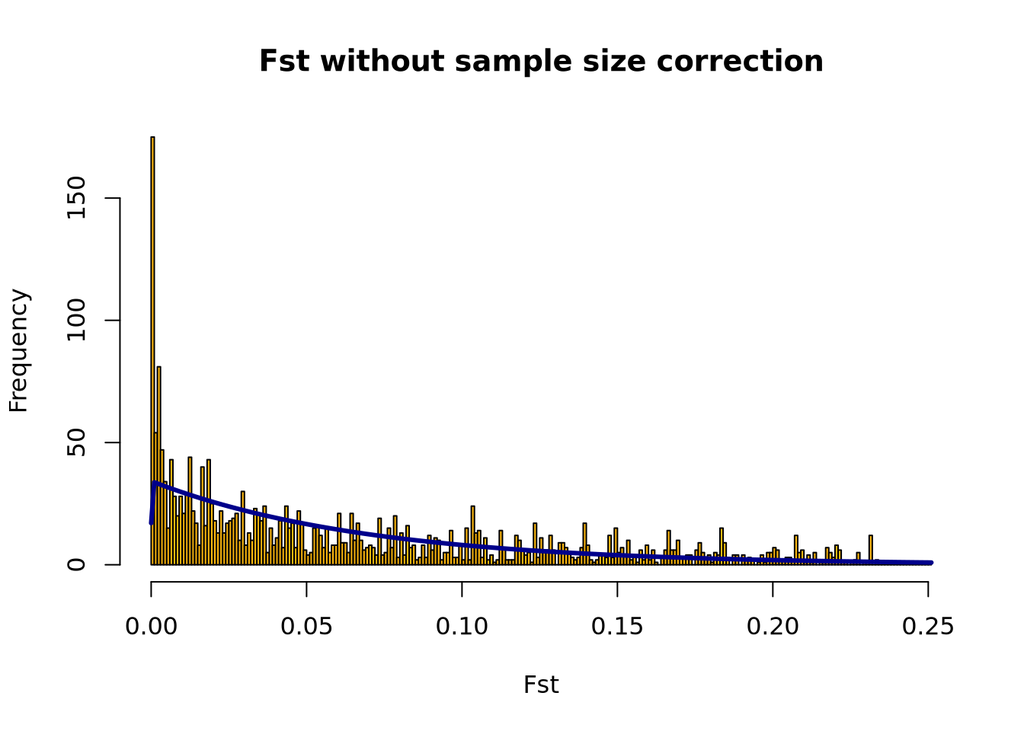

```r
OutFLANKResultsPlotter(
  out_trim_ma,
  withOutliers = TRUE, NoCorr = TRUE, Hmin = 0.1,
  binwidth = 0.001, Zoom = FALSE, RightZoomFraction = 0.05, titletext = NULL
)
```

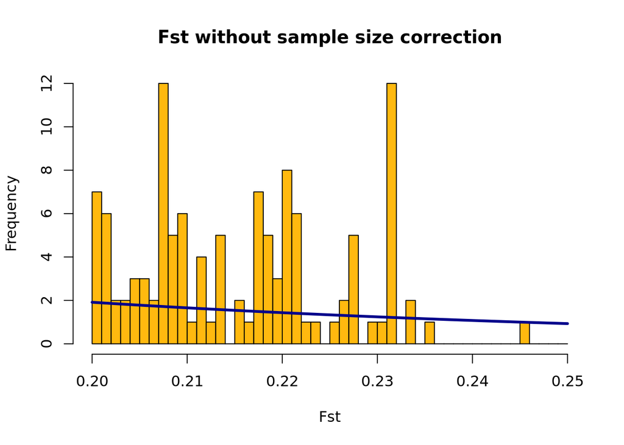

```r
OutFLANKResultsPlotter(
  out_trim_ma,
  withOutliers = TRUE, NoCorr = TRUE, Hmin = 0.1,
  binwidth = 0.001, Zoom = TRUE, RightZoomFraction = 0.05, titletext = NULL
)
```

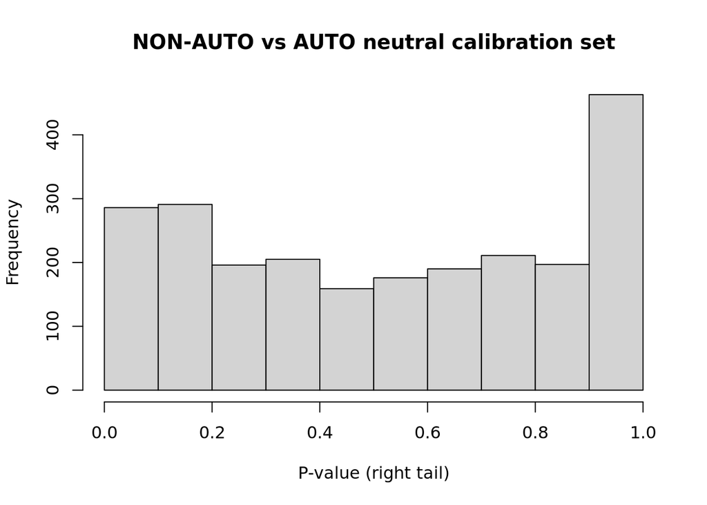

```r
hist(out_trim_ma$results$pvaluesRightTail,
     xlab = "P-value (right tail)", main = "NON-AUTO vs AUTO neutral calibration set")
```

### 4.2 Scan across all loci

```bash
plink2 \
--bfile output/outflank/man_aut \
--export vcf \
--make-bed \
--out output/outflank/man_aut4 \
--silent;
grep "samples\|variants" output/outflank/man_aut4.log
```

```
## 38 samples (13 females, 15 males, 10 ambiguous; 38 founders) loaded from
## 41332 variants loaded from output/outflank/man_aut.bim.
```

```r
P1_ma <- run_outflank_scan(
  here("output", "outflank", "man_aut4.vcf"),
  out_trim_ma
)
```

```
## Scanning file to determine attributes.
## File attributes:
##   meta lines: 8
##   header_line: 9
##   variant count: 41332
##   column count: 47
## Meta line 8 read in.
## All meta lines processed.
## gt matrix initialized.
## Character matrix gt created.
##   Character matrix gt rows: 41332
##   Character matrix gt cols: 47
##   skip: 0
##   nrows: 41332
##   row_num: 0
## Processed variant 1000Processed variant 2000Processed variant 3000Processed variant 4000Processed variant 5000Processed variant 6000Processed variant 7000Processed variant 8000Processed variant 9000Processed variant 10000Processed variant 11000Processed variant 12000Processed variant 13000Process…
## All variants processed
## Calculating FSTs, may take a few minutes...
## [1] "10000 done of 41332"
## [1] "20000 done of 41332"
## [1] "30000 done of 41332"
## [1] "40000 done of 41332"
```

```r
my_out_ma <- P1_ma$SNP_id[P1_ma$OutlierFlag == TRUE]
write.table(
  my_out_ma,
  file      = here("output", "outflank", "man_aut_SNPs_outFlank.txt"),
  row.names = FALSE, quote = FALSE, col.names = FALSE, sep = "\n"
)
```

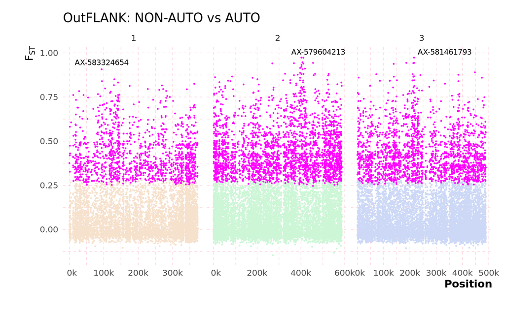

```r
p_ma <- plot_outflank_manhattan(
  P1_ma,
  here("output", "outflank", "man_aut.bim"),
  title = "OutFLANK: NON-AUTO vs AUTO"
)
print(p_ma)
```

```r
ggsave(
  here("output", "outflank", "figures", "man_aut_outFlank_outliers.pdf"),
  width = 8, height = 5, units = "in"
)
```

## 5. OutFLANK: NON-AUTO-FIELD vs AUTO (NEW vs AUT)

### 5.1 Neutral SNP calibration set

```bash
plink2 \
--bfile output/outflank/new_aut \
--extract output/outflank/indepSNP.prune.in \
--export vcf \
--make-bed \
--out output/outflank/new_aut2 \
--silent;
grep 'samples\|variants\|remaining' output/outflank/new_aut2.log
```

```
## 50 samples (24 females, 26 males; 50 founders) loaded from
## 41696 variants loaded from output/outflank/new_aut.bim.
## --extract: 3724 variants remaining.
## 3724 variants remaining after main filters.
```

```r
dat_na2 <- vcf_to_genotype_matrix(here("output", "outflank", "new_aut2.vcf"))
```

```
## Scanning file to determine attributes.
## File attributes:
##   meta lines: 8
##   header_line: 9
##   variant count: 3724
##   column count: 59
## Meta line 8 read in.
## All meta lines processed.
## gt matrix initialized.
## Character matrix gt created.
##   Character matrix gt rows: 3724
##   Character matrix gt cols: 59
##   skip: 0
##   nrows: 3724
##   row_num: 0
## Processed variant 1000Processed variant 2000Processed variant 3000Processed variant: 3724
## All variants processed
```

```r
my_fst_na2 <- MakeDiploidFSTMat(
  dat_na2$G, locusNames = dat_na2$snpNames, popNames = dat_na2$popNames
)
```

```
## Calculating FSTs, may take a few minutes...
```

```r
neutral_na <- my_fst_na2 |> filter(FST < 0.2 & FST >= -0.1) |> pull(LocusName)
write.table(
  neutral_na,
  file      = here("output", "outflank", "new_aut2_SNPs.txt"),
  row.names = FALSE, quote = FALSE, col.names = FALSE, sep = "\n"
)
```

```bash
plink2 \
--bfile output/outflank/new_aut2 \
--export vcf \
--extract output/outflank/new_aut2_SNPs.txt \
--out output/outflank/new_aut3 \
--silent;
grep "samples\|variants" output/outflank/new_aut3.log
```

```
## 50 samples (24 females, 26 males; 50 founders) loaded from
## 3724 variants loaded from output/outflank/new_aut2.bim.
## --extract: 3078 variants remaining.
## 3078 variants remaining after main filters.
```

```r
dat_na3 <- vcf_to_genotype_matrix(here("output", "outflank", "new_aut3.vcf"))
```

```
## Scanning file to determine attributes.
## File attributes:
##   meta lines: 8
##   header_line: 9
##   variant count: 3078
##   column count: 59
## Meta line 8 read in.
## All meta lines processed.
## gt matrix initialized.
## Character matrix gt created.
##   Character matrix gt rows: 3078
##   Character matrix gt cols: 59
##   skip: 0
##   nrows: 3078
##   row_num: 0
## Processed variant 1000Processed variant 2000Processed variant 3000Processed variant: 3078
## All variants processed
```

```r
my_fst_na3 <- MakeDiploidFSTMat(
  dat_na3$G, locusNames = dat_na3$snpNames, popNames = dat_na3$popNames
)
```

```
## Calculating FSTs, may take a few minutes...
```

```r
# NOTE: NumberOfSamples=60 preserved. FLAG: should be 2 (populations) for pairwise comparisons.
out_trim_na <- OutFLANK(
  FstDataFrame    = my_fst_na3,
  Hmin            = 0.1,
  NumberOfSamples = 60,
  qthreshold      = 0.05
)
```

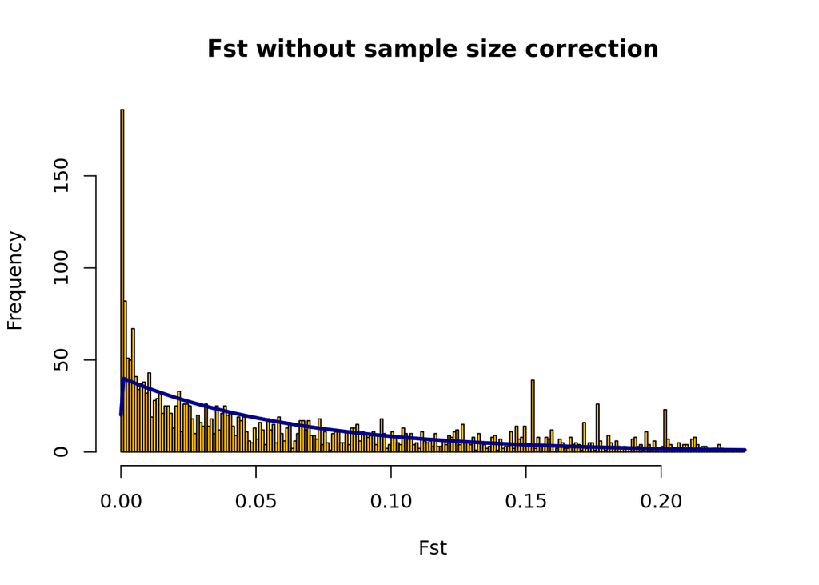

```r
OutFLANKResultsPlotter(
  out_trim_na,
  withOutliers = TRUE, NoCorr = TRUE, Hmin = 0.1,
  binwidth = 0.001, Zoom = FALSE, RightZoomFraction = 0.05, titletext = NULL
)
```

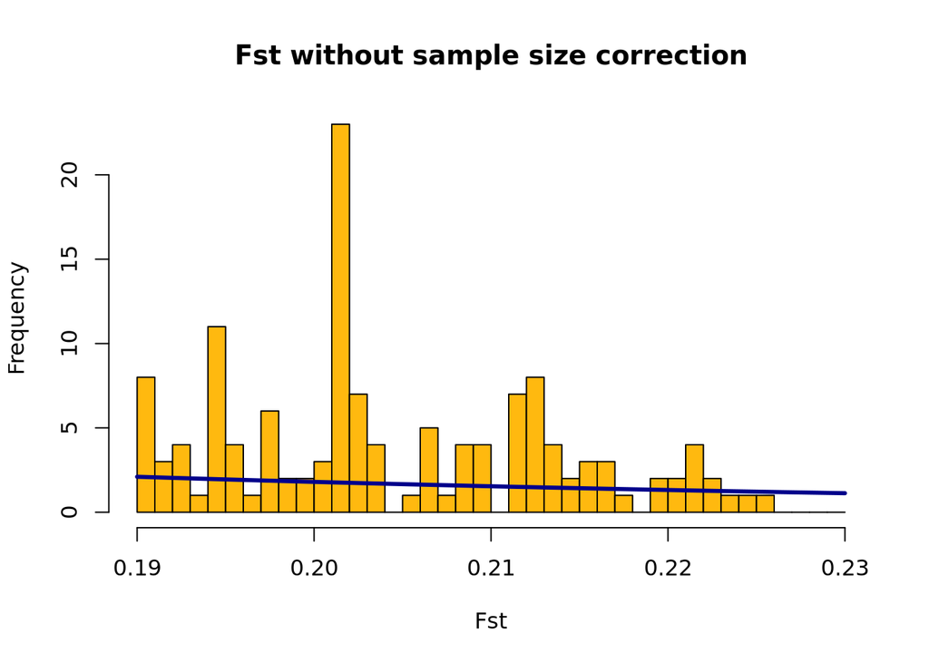

```r
OutFLANKResultsPlotter(
  out_trim_na,
  withOutliers = TRUE, NoCorr = TRUE, Hmin = 0.1,
  binwidth = 0.001, Zoom = TRUE, RightZoomFraction = 0.05, titletext = NULL
)
```

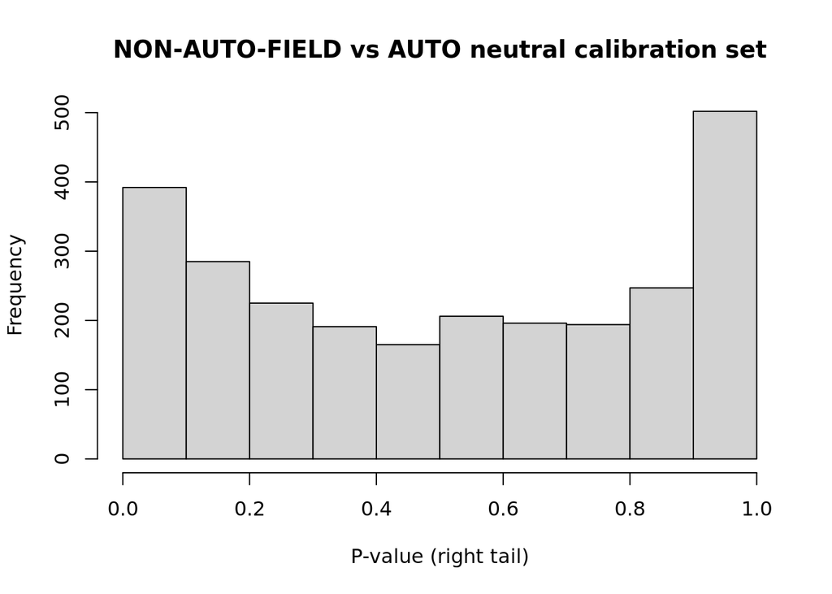

```r
hist(out_trim_na$results$pvaluesRightTail,
     xlab = "P-value (right tail)", main = "NON-AUTO-FIELD vs AUTO neutral calibration set")
```

### 5.2 Scan across all loci

```bash
plink2 \
--bfile output/outflank/new_aut \
--export vcf \
--make-bed \
--out output/outflank/new_aut4 \
--silent;
grep "samples\|variants" output/outflank/new_aut4.log
```

```
## 50 samples (24 females, 26 males; 50 founders) loaded from
## 41696 variants loaded from output/outflank/new_aut.bim.
```

```r
P1_na <- run_outflank_scan(
  here("output", "outflank", "new_aut4.vcf"),
  out_trim_na
)
```

```
## Scanning file to determine attributes.
## File attributes:
##   meta lines: 8
##   header_line: 9
##   variant count: 41696
##   column count: 59
## Meta line 8 read in.
## All meta lines processed.
## gt matrix initialized.
## Character matrix gt created.
##   Character matrix gt rows: 41696
##   Character matrix gt cols: 59
##   skip: 0
##   nrows: 41696
##   row_num: 0
## Processed variant 1000Processed variant 2000Processed variant 3000Processed variant 4000Processed variant 5000Processed variant 6000Processed variant 7000Processed variant 8000Processed variant 9000Processed variant 10000Processed variant 11000Processed variant 12000Processed variant 13000Process…
## All variants processed
## Calculating FSTs, may take a few minutes...
## [1] "10000 done of 41696"
## [1] "20000 done of 41696"
## [1] "30000 done of 41696"
## [1] "40000 done of 41696"
```

```r
my_out_na <- P1_na$SNP_id[P1_na$OutlierFlag == TRUE]
write.table(
  my_out_na,
  file      = here("output", "outflank", "new_aut_SNPs_outFlank.txt"),
  row.names = FALSE, quote = FALSE, col.names = FALSE, sep = "\n"
)
```

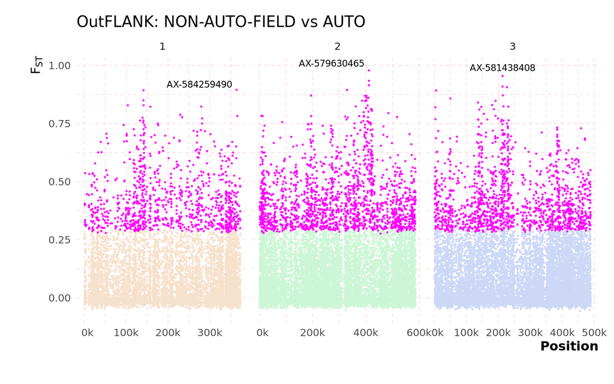

```r
p_na <- plot_outflank_manhattan(
  P1_na,
  here("output", "outflank", "new_aut.bim"),
  title = "OutFLANK: NON-AUTO-FIELD vs AUTO"
)
print(p_na)
```

```r
ggsave(
  here("output", "outflank", "figures", "new_aut_outFlank_outliers.pdf"),
  width = 8, height = 5, units = "in"
)
```

## 6. OutFLANK: NON-AUTO vs NON-AUTO-FIELD (MAN vs NEW)

### 6.1 Neutral SNP calibration set

```bash
plink2 \
--bfile output/outflank/man_new \
--extract output/outflank/indepSNP.prune.in \
--export vcf \
--make-bed \
--out output/outflank/man_new2 \
--silent;
grep 'samples\|variants\|remaining' output/outflank/man_new2.log
```

```
## 32 samples (11 females, 11 males, 10 ambiguous; 32 founders) loaded from
## 41206 variants loaded from output/outflank/man_new.bim.
## --extract: 3720 variants remaining.
## 3720 variants remaining after main filters.
```

```r
dat_mn2 <- vcf_to_genotype_matrix(here("output", "outflank", "man_new2.vcf"))
```

```
## Scanning file to determine attributes.
## File attributes:
##   meta lines: 8
##   header_line: 9
##   variant count: 3720
##   column count: 41
## Meta line 8 read in.
## All meta lines processed.
## gt matrix initialized.
## Character matrix gt created.
##   Character matrix gt rows: 3720
##   Character matrix gt cols: 41
##   skip: 0
##   nrows: 3720
##   row_num: 0
## Processed variant 1000Processed variant 2000Processed variant 3000Processed variant: 3720
## All variants processed
```

```r
my_fst_mn2 <- MakeDiploidFSTMat(
  dat_mn2$G, locusNames = dat_mn2$snpNames, popNames = dat_mn2$popNames
)
```

```
## Calculating FSTs, may take a few minutes...
```

```r
neutral_mn <- my_fst_mn2 |> filter(FST < 0.2 & FST >= -0.1) |> pull(LocusName)
write.table(
  neutral_mn,
  file      = here("output", "outflank", "man_new2_SNPs.txt"),
  row.names = FALSE, quote = FALSE, col.names = FALSE, sep = "\n"
)
```

```bash
plink2 \
--bfile output/outflank/man_new2 \
--export vcf \
--extract output/outflank/man_new2_SNPs.txt \
--out output/outflank/man_new3 \
--silent;
grep "samples\|variants" output/outflank/man_new3.log
```

```
## 32 samples (11 females, 11 males, 10 ambiguous; 32 founders) loaded from
## 3720 variants loaded from output/outflank/man_new2.bim.
## --extract: 3452 variants remaining.
## 3452 variants remaining after main filters.
```

```r
dat_mn3 <- vcf_to_genotype_matrix(here("output", "outflank", "man_new3.vcf"))
```

```
## Scanning file to determine attributes.
## File attributes:
##   meta lines: 8
##   header_line: 9
##   variant count: 3452
##   column count: 41
## Meta line 8 read in.
## All meta lines processed.
## gt matrix initialized.
## Character matrix gt created.
##   Character matrix gt rows: 3452
##   Character matrix gt cols: 41
##   skip: 0
##   nrows: 3452
##   row_num: 0
## Processed variant 1000Processed variant 2000Processed variant 3000Processed variant: 3452
## All variants processed
```

```r
my_fst_mn3 <- MakeDiploidFSTMat(
  dat_mn3$G, locusNames = dat_mn3$snpNames, popNames = dat_mn3$popNames
)
```

```
## Calculating FSTs, may take a few minutes...
```

```r
# NOTE: NumberOfSamples=60 preserved. FLAG: should be 2 (populations) for pairwise comparisons.
out_trim_mn <- OutFLANK(
  FstDataFrame    = my_fst_mn3,
  Hmin            = 0.1,
  NumberOfSamples = 60,
  qthreshold      = 0.05
)
```

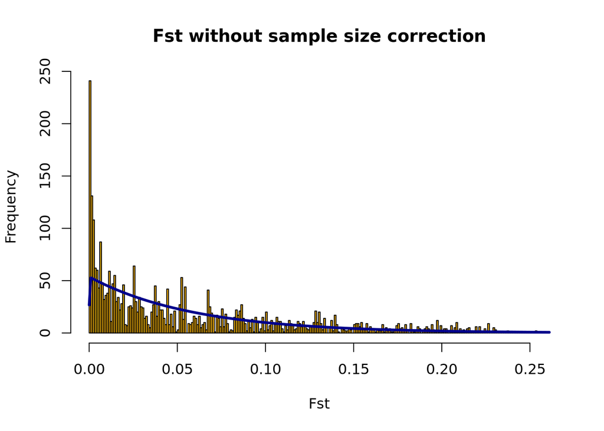

```r
OutFLANKResultsPlotter(
  out_trim_mn,
  withOutliers = TRUE, NoCorr = TRUE, Hmin = 0.1,
  binwidth = 0.001, Zoom = FALSE, RightZoomFraction = 0.05, titletext = NULL
)
```

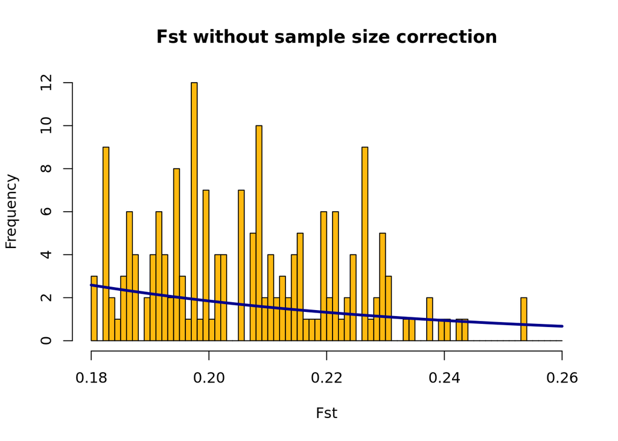

```r
OutFLANKResultsPlotter(
  out_trim_mn,
  withOutliers = TRUE, NoCorr = TRUE, Hmin = 0.1,
  binwidth = 0.001, Zoom = TRUE, RightZoomFraction = 0.05, titletext = NULL
)
```

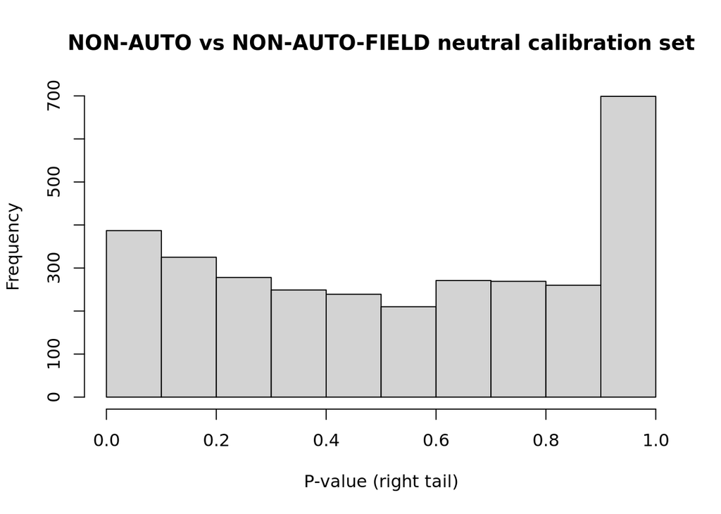

```r
hist(out_trim_mn$results$pvaluesRightTail,
     xlab = "P-value (right tail)", main = "NON-AUTO vs NON-AUTO-FIELD neutral calibration set")
```

### 6.2 Scan across all loci

No FST outliers are expected between the two non-autogenous populations.

```bash
plink2 \
--bfile output/outflank/man_new \
--export vcf \
--make-bed \
--out output/outflank/man_new4 \
--silent;
grep "samples\|variants" output/outflank/man_new4.log
```

```
## 32 samples (11 females, 11 males, 10 ambiguous; 32 founders) loaded from
## 41206 variants loaded from output/outflank/man_new.bim.
```

```r
P1_mn <- run_outflank_scan(
  here("output", "outflank", "man_new4.vcf"),
  out_trim_mn
)
```

```
## Scanning file to determine attributes.
## File attributes:
##   meta lines: 8
##   header_line: 9
##   variant count: 41206
##   column count: 41
## Meta line 8 read in.
## All meta lines processed.
## gt matrix initialized.
## Character matrix gt created.
##   Character matrix gt rows: 41206
##   Character matrix gt cols: 41
##   skip: 0
##   nrows: 41206
##   row_num: 0
## Processed variant 1000Processed variant 2000Processed variant 3000Processed variant 4000Processed variant 5000Processed variant 6000Processed variant 7000Processed variant 8000Processed variant 9000Processed variant 10000Processed variant 11000Processed variant 12000Processed variant 13000Process…
## All variants processed
## Calculating FSTs, may take a few minutes...
## [1] "10000 done of 41206"
## [1] "20000 done of 41206"
## [1] "30000 done of 41206"
## [1] "40000 done of 41206"
```

## 7. Venn diagrams

> **Note:** This section was not used in the final version of the manuscript.

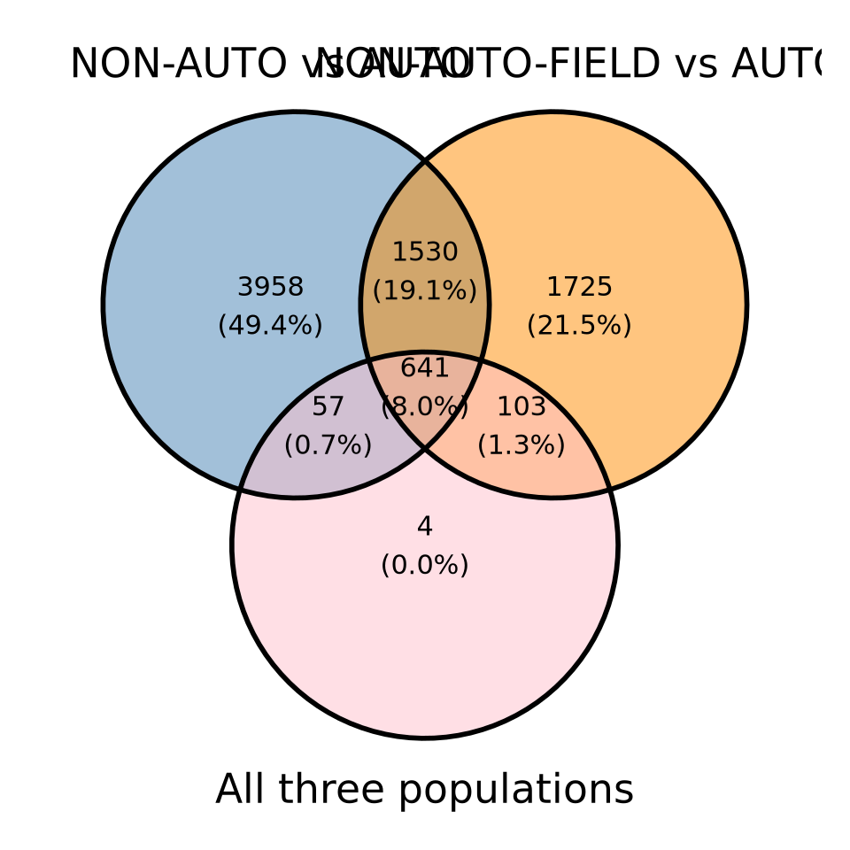

```r
MAN_AUT <- read.table(
  here("output", "outflank", "man_aut_SNPs_outFlank.txt"),
  stringsAsFactors = FALSE
) |> drop_na()

NEW_AUT <- read.table(
  here("output", "outflank", "new_aut_SNPs_outFlank.txt"),
  stringsAsFactors = FALSE
)

NEW_MAN_AUT <- read.table(
  here("output", "outflank", "SNPs_outFlank.txt"),
  stringsAsFactors = FALSE
)

list_of_clusters <- list(
  "NON-AUTO vs AUTO"       = MAN_AUT$V1,
  "NON-AUTO-FIELD vs AUTO" = NEW_AUT$V1,
  "All three populations"  = NEW_MAN_AUT$V1
)

venn_diagram <- ggvenn(list_of_clusters, fill_color = c("steelblue", "darkorange", "pink"))
print(venn_diagram)
```

```r
common_SNPs <- Reduce(intersect, list_of_clusters)
write.table(
  common_SNPs,
  file      = here("output", "pcadapt", "common_SNPs_NEW_MAN_AUT.txt"),
  row.names = FALSE, col.names = FALSE, quote = FALSE
)

output_path <- here("output", "pcadapt", "figures", "significant_snps_NEW_MAN_AUT.pdf")
ggsave(output_path, venn_diagram, height = 5, width = 5, dpi = 300)
```